# Table of Content

- 1. Getting Ready
- 2. Sanity Checking & Data Cleaning
  - 2.1. Sanity Checking
  - 2.2. Data Cleaning
- 3. Exploratory Data Analysis
  - 3.1. Univarate Data Analysis I
  - 3.2. What do we learn from above bar plots?
  - 3.3 Univarate data analysis II
  - 3.4 What do we learn from above histograms?
  - 3.5 Boxplots for Age, Duration and Campaign
  - 3.6 Bivarate data analysis
- 4. Data Preprocessing
  - 4.1 Split data into train and test
  - 4.2 Handle data Multicollinearity
  - 4.3 Detecting and treating on outliers
  - 4.4 Feature Engineering on Categorical Data
  - 4.5 Use SMOTE to Balance the dataset
- 5. Staring from Logistic Regression
- 6. Random Forest
- 7. KNN
- 8. Stochastic Gradient Boosting
- 9. Model Evaluation

# 1. Getting Ready

```python
# Basic
import numpy as np
import pandas as pd
import matplotlib.pyplot as plt
import seaborn as sns
import matplotlib.patches as mpatches
%matplotlib inline
pd.set_option('display.max_rows', 500)
pd.set_option('display.max_columns', 500)
pd.set_option('display.width', 1000)

# Statistic models and Machine Learning
import statsmodels.api as sm
from statsmodels.stats.outliers_influence import variance_inflation_factor
from statsmodels.tools.tools import add_constant
from sklearn import preprocessing
from sklearn.metrics import accuracy_score
from sklearn.metrics import roc_curve
from sklearn.metrics import roc_auc_score
from sklearn.ensemble import RandomForestClassifier
from sklearn.linear_model import LogisticRegression
from sklearn import svm
from sklearn.svm import SVC, LinearSVC
from sklearn.inspection import permutation_importance
from sklearn.neighbors import KNeighborsClassifier
from sklearn.model_selection import train_test_split
from imblearn import under_sampling, over_sampling
from imblearn.over_sampling import SMOTE


#Model Evaluation
from numpy import loadtxt
from sklearn.model_selection import KFold
from sklearn.model_selection import cross_val_score
from sklearn.model_selection import cross_val_predict
from sklearn.metrics import confusion_matrix
from sklearn.metrics import precision_score, recall_score
```

```python
# Data Loading
df = pd.read_csv('Bank.csv')
```

```python
# shape and data types of the data
print(df.shape)
#print(df.dtypes)

# Looking at the first ten rows/basic descriptive statistics of the dataset
#print(df.head(10))
```

```
(41188, 21)
```

```python
df.describe()
```

|  | age | duration | campaign | pdays | previous | emp.var.rate | cons.price.idx | cons.conf.idx | euribor3m | nr.employed |
| --- | --- | --- | --- | --- | --- | --- | --- | --- | --- | --- |
| count | 41188.00000 | 41188.000000 | 41188.000000 | 41188.000000 | 41188.000000 | 41188.000000 | 41188.000000 | 41188.000000 | 41188.000000 | 41188.000000 |
| mean | 40.02406 | 258.285010 | 2.567593 | 962.475454 | 0.172963 | 0.081886 | 93.575664 | -40.502600 | 3.621291 | 5167.035911 |
| std | 10.42125 | 259.279249 | 2.770014 | 186.910907 | 0.494901 | 1.570960 | 0.578840 | 4.628198 | 1.734447 | 72.251528 |
| min | 17.00000 | 0.000000 | 1.000000 | 0.000000 | 0.000000 | -3.400000 | 92.201000 | -50.800000 | 0.634000 | 4963.600000 |
| 25% | 32.00000 | 102.000000 | 1.000000 | 999.000000 | 0.000000 | -1.800000 | 93.075000 | -42.700000 | 1.344000 | 5099.100000 |
| 50% | 38.00000 | 180.000000 | 2.000000 | 999.000000 | 0.000000 | 1.100000 | 93.749000 | -41.800000 | 4.857000 | 5191.000000 |
| 75% | 47.00000 | 319.000000 | 3.000000 | 999.000000 | 0.000000 | 1.400000 | 93.994000 | -36.400000 | 4.961000 | 5228.100000 |
| max | 98.00000 | 4918.000000 | 56.000000 | 999.000000 | 7.000000 | 1.400000 | 94.767000 | -26.900000 | 5.045000 | 5228.100000 |

# 2. Sanity Checking & Data Cleaning

## 2.1. Sanity Checking

- What are the sanity checking rules for the banking data set?

> 1)If a customer was not previously contacted in the last campaign, then the outcome of last campaign to this customer should be "nonexistent";

> 2) If a customer was previously contacted in the last campaign, then the outcome of last campaign to this customer should be "success" or "failure";

> 3) If the outcome of this campaign is "yes" to a client, then the duration of contact should be greater than 0;

> 4) Some numeric values should be greater or equal to zero. They are: "Age", "duration", "campaign", "pdays", "previous" and "nr.employeed";

> 5) There should be no duplicated rows or missing values in the data.

```python
############Sanity Checking on Previous Campaign related columns############################
##First, for all records, when pdays = 999, previous should be equal to 0:
pday_999 = df.loc[(df['pdays'] == 999) & (df['previous'] != 0) ]
#print(pday_999) # There are 4110 erroneous records based on the above condition;
pday_999.y.value_counts()
#There are 532 records are related to positive labels on our target,
#so instead of dropping them, we make a more flexible assumption：column pdays is missing even though poutcome is available
#Let's create an indicator variable for missing 'pdays'.
df["pdays_in"] = np.where((df['pdays'] == 999) & (df['previous'] != 0), 1, 0)
df.pdays_in.value_counts()
print(df.shape) #one more column was added.
```

```
(41188, 22)
```

```python
##Second, when pdays = 999, previous = 0, poutcome should be nonexistent:
pday_none = df.loc[(df['pdays'] == 999) & (df['previous'] == 0) ]
#print(pday_none)
rslt_df_1 = pday_none.loc[(pday_none['poutcome'] != 'nonexistent')]
#print(rslt_df_1)   #No erroneous records found.

##Lastly, when pdays != 999 and previous != 0, poutcome should be "success" or 'failure":
pday_yes = df.loc[(df['pdays'] != 999) & (df['previous'] != 0) ]
#print(pday_yes)
options = ['success', 'failure']
rslt_df_2 = pday_yes.loc[~pday_yes['poutcome'].isin(options)]
print(rslt_df_2)  #No erroneous records found.
```

```
Empty DataFrame
Columns: [age, job, marital, education, default, housing, loan, contact, month, day_of_week, duration, campaign, pdays, previous, poutcome, emp.var.rate, cons.price.idx, cons.conf.idx, euribor3m, nr.employed, y, pdays_in]
Index: []
```

```python
############Sanity Checking on other columns############################
##If the outcome of this campaign is "yes" to a client, then the duration of contact should be greater than 0;
result_yes =df.loc[(df['y'] == 'yes')]
#print(result_yes)
rslt_df_3 = result_yes.loc[(result_yes['duration'] == 0)]
#print(rslt_df_3)   #No erroneous records found.

##Some numeric values should be greater or equal to zero. They are: "Age", "duration", "campaign", "pdays", "previous" and "nr.employeed";
rslt_df_4 = df[(df['age'] <= 0) | (df['duration'] < 0) | (df['campaign'] < 0) | (df['pdays'] < 0) | (df['previous'] < 0) | (df['nr.employed'] < 0)]
#print(rslt_df_4)  #No erroneous records found.
```

## 2.2. Data Cleaning

```python
#Any missing values?
df.isnull().sum()
#no numerical missing values were found;
# There are "unknown" values in categorical variables, instead of dropping them, we will treat them as a sperate category;
```

```
age               0
job               0
marital           0
education         0
default           0
housing           0
loan              0
contact           0
month             0
day_of_week       0
duration          0
campaign          0
pdays             0
previous          0
poutcome          0
emp.var.rate      0
cons.price.idx    0
cons.conf.idx     0
euribor3m         0
nr.employed       0
y                 0
pdays_in          0
dtype: int64
```

```python
# Drop duplicates before move to the next step!!
df = df.drop_duplicates()
df.shape
```

```
(41176, 22)
```

# 3. Exploratory Data Analysis

## 3.1. Univarate Data Analysis I

- Bar Plots for Categorical Variables:

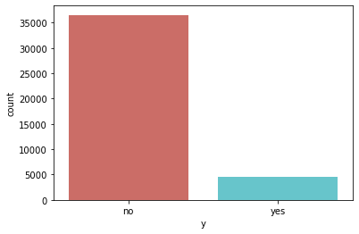

```
0.850009714396736
```

```python
####################First, take a look on distribution of the response variable################################
sns.countplot(x = 'y', data = df, palette = 'hls')
plt.show()
plt.savefig('count_plot')
# two classes of our response variable are very imbalanced, we need to fix this later;
df.groupby('y').mean()
35000/41176
```

```python
#univariate analysis of categorical variables
#select non numeric columns
df_non_numeric = df.select_dtypes(exclude=[np.number])
non_numeric_cols = df_non_numeric.columns.values
print(non_numeric_cols)
```

```
['job' 'marital' 'education' 'default' 'housing' 'loan' 'contact' 'month'
 'day_of_week' 'poutcome' 'y']
```

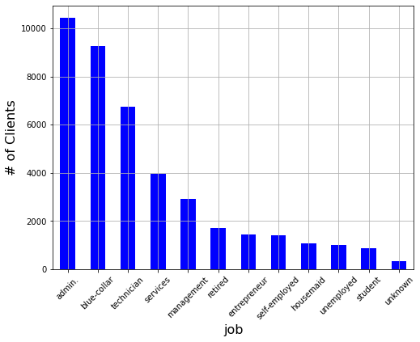

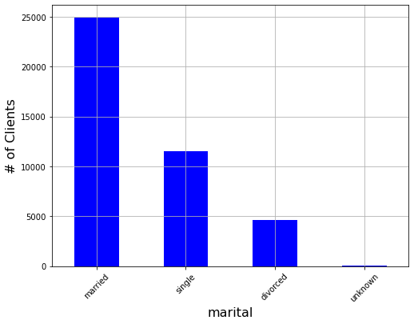

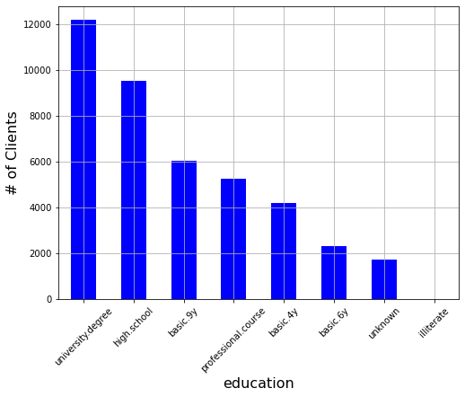

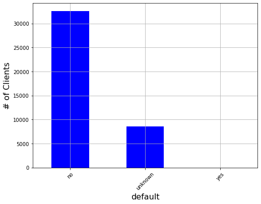

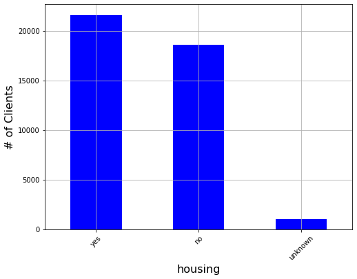

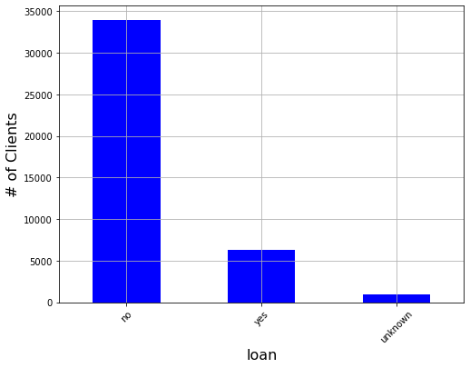

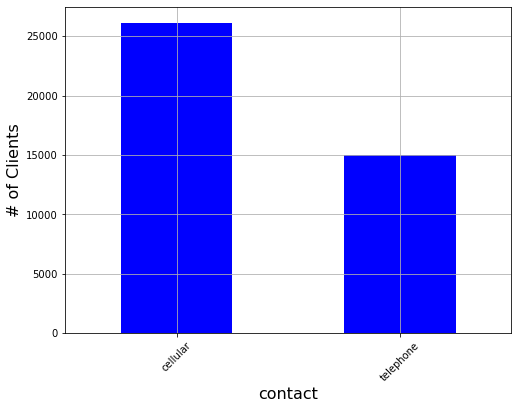

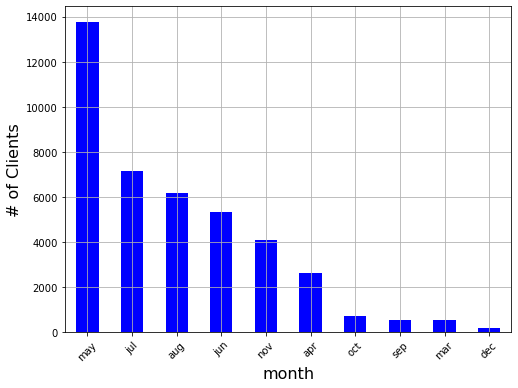

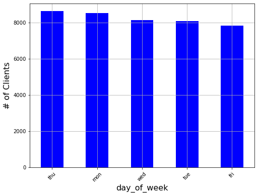

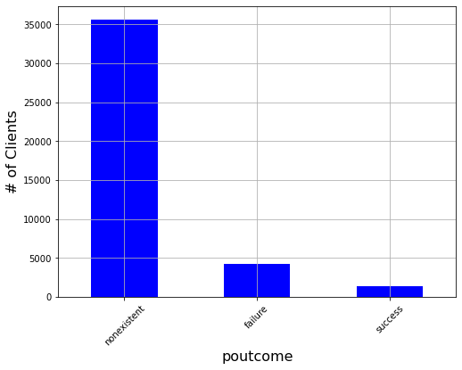

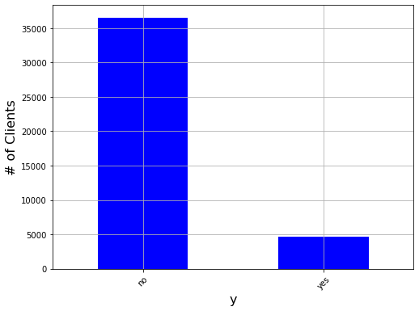

```python
#plot the bar graph for non-numerical variables use one function
for column in non_numeric_cols:
    plt.figure(figsize=(15,8))
    large_to_small = df.groupby(column).size().sort_values().index[::-1]
    df[column].value_counts().plot(kind="bar",rot=45, color="b",
                                           grid = 'true',
                                           figsize=(8,6))
    plt.xlabel(column,fontsize=16)
    plt.ylabel("# of Clients",fontsize=16)
```